# RcppArmadillo

20 juillet 2018

## RcppArmadillo : lien entre C++ et R

Dans un fichier Cpp :

```cpp
#include "RcppArmadillo.h"
using namespace arma;  // Evite d'écrire arma::fonctionArmadillo
// [[Rcpp::depends(RcppArmadillo)]]

// [[Rcpp::export]] // Importe la fonction qui suit dans l'environnement global de R
mat addition(int a, mat M) {
  return a + M;
}
```

## RcppArmadillo : lien entre C++ et R

Dans un fichier R :

```r
library(Rcpp)
sourceCpp("addition.cpp")
a <- 1
M <- matrix(1:4,2)
sumIntMat <- addition(a,M)
```

## RcppArmadillo : débugger du code C++

Ici on omet volontairement la commande namespace, il faut donc préciser à quel package appartiennent les fonctions.

```cpp
#include "RcppArmadillo.h"
// [[Rcpp::depends(RcppArmadillo)]]

// [[Rcpp::export]]
void printMatrix(arma::mat X) {
  X.print();
}
// [[Rcpp::export]]
void showMatrix(arma::mat X) {
  Rcpp::Rcout << "Armadillo matrix is" << std::endl << X << std::endl;
}
```

## RcppArmadillo : débugger du code C++

On peut ajouter une balise R directement dans le C++, ceci compilera le R en "sourçant" le code C++. On peut ainsi tester directement dans le fichier C++, en utilisant R, les fonctons écrites en C++.

```cpp
/*** R
M <- matrix(1:4,2)
printMatrix(M)
showMatrix(M)
*/
```

## Documentation Armadillo

[http://arma.sourceforge.net/"](http://arma.sourceforge.net/)

## TP RcppArmadillo : factorielle

Exercice :

1. Coder la fonction factorielle (récursivement et avec des boucles) en R et en C++.
2. Mesurer le temps d'éxécution des 4 fonctions pour n = 10,100,1000.

## TP RcppArmadillo : correction code R

```r
factorielleR_Rec <- function(n) {
  if(n==1){
    return(1)
  } else {
    return(n*factorielleR_Rec(n-1))
  }
}
factorielleR_Loop <- function(n) {
  prod <- 1
  for (i in 1:n) {
    prod <- prod*i
  }
  prod  # Pas besoin de return ici en R
}
```

## TP RcppArmadillo : correction code C++

```cpp
double factorielleCpp_Rec(double n) {  // Le type de retour est crucial (source d'erreur)
  if(n==1) {
    return 1;  // Ne pas oublier le ";" !
  } else {
    return n*factorielleCpp_Rec(n-1); // Pas de parenthèses !
  }
}
double factorielleCpp_Loop(double n) {
  double prod = 1;  // Important : il faut initialiser les variables
  for(double i=1;i<=n;i++){
    prod *= i;
  }
  return prod;
}
```

## TP RcppArmadillo : correction benchmark

```r
library(microbenchmark)
library(Rcpp)
library(ggplot2)
source("factorielle.R")
sourceCpp("factorielle.cpp")

n <- 100
tm <- microbenchmark(factorielleR_Rec(n),
                     factorielleCpp_Rec(n),
                     factorielleR_Loop(n),
                     factorielleCpp_Loop(n), times=1000L)
```

## TP RcppArmadillo : correction benchmark (plot)

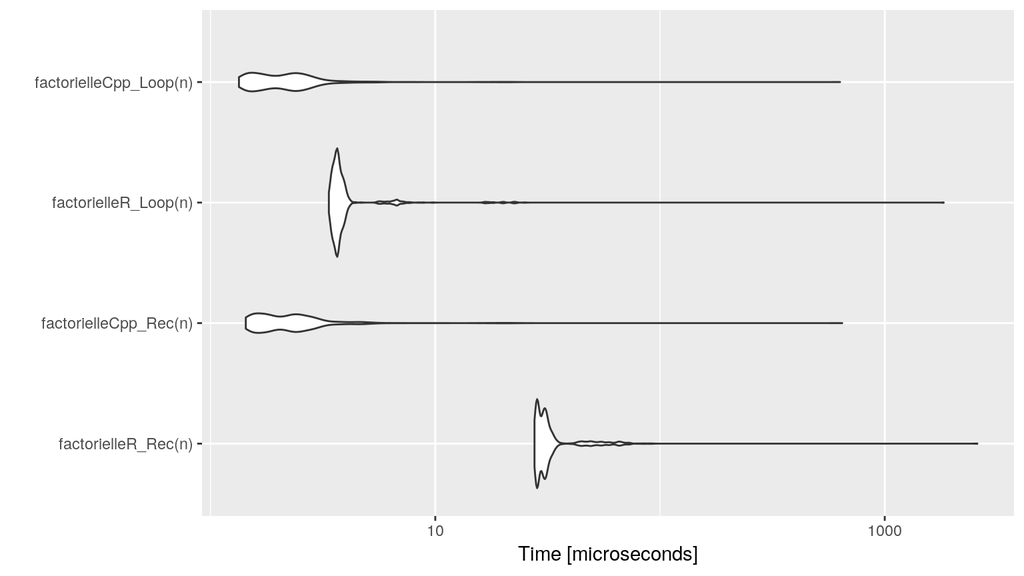

```r
autoplot(tm)
```

## TP RcppArmadillo : vectoriser vs boucle

Exercice :

1. Écrire la quantité \(\sum_{q,\ell = 1}^Q \alpha_q \alpha_{\ell}\pi_{q\ell}\) sous forme vectorielle.
2. Comparer en R et en C++ le temps d'éxécution des codes (boucles et produit matriciel).

## TP RcppArmadillo : correction code R

```r
formeBilinR_Loop <- function(alpha, pi) {
  Q <- length(alpha)
  sum <- 0
  for(q in 1:Q){
    for (l in 1:Q) {
      sum <- sum + alpha[q]*alpha[l]*pi[q,l]
    }
  }
  sum
}
formeBilinR_Prod <- function(alpha, pi) {
  sum <- t(alpha) %*% pi %*% alpha
  sum
}
```

## TP RcppArmadillo : correction code C++

```cpp
double formeBilinCpp_Loop(vec alpha, mat pi) {
  int Q = pi.n_cols;
  double sum = 0;
  for (int q=0; q<Q; q++) {
    for(int l=0; l<Q; l++) {
      sum += alpha[q]*alpha[l]*pi(q,l); // Attention aux parenthèses et crochets !
    }
  }
  return sum;
}
double formeBilinCpp_Prod(vec alpha, mat pi) {
  double sum = as_scalar(alpha.t() * pi * alpha);  // Attention aux types !
  return sum;
}
```

## TP RcppArmadillo : correction benchmark

```r
library(microbenchmark)
library(ggplot2)
source("formeBilin.R")
sourceCpp("formeBilin.cpp")

alpha <- 1:100
pi    <- matrix(1,100,100)

tm <- microbenchmark(formeBilinR_Loop(alpha,pi),
                     formeBilinCpp_Loop(alpha,pi),
                     formeBilinR_Prod(alpha,pi),
                     formeBilinCpp_Prod(alpha,pi), times=1000L)
```

## TP RcppArmadillo : correction benchmark (plot)

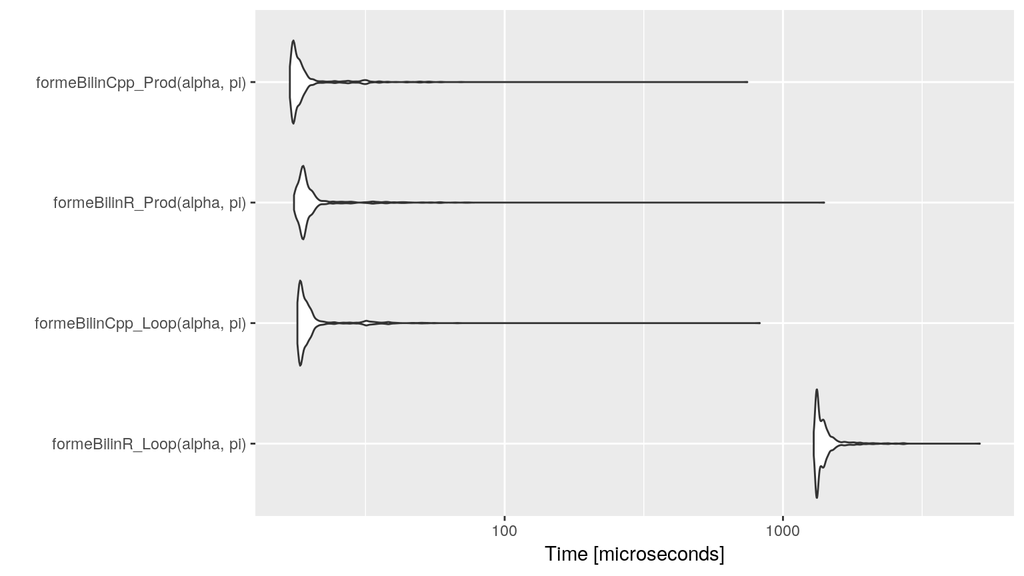

```r
autoplot(tm)
```

## TP RcppArmadillo : TP d'optimisation

1. Écrire une fonction norme euclidienne au carré d'un vecteur en C++.
2. Écrire une fonction fr(vec theta, vec X) qui calcule la vraisemblance du vecteur X de gaussiennes de paramètres theta.
3. Écrire une fonction grr(vec theta, vec X) qui calcule le gradient de la vraisemblance du vecteur X de gaussiennes de paramètres theta.
4. Simuler 100 gaussiennes de vos paramètres préférés et les estimer avec la fonction optim de R en utilisant fr et grr.

## TP RcppArmadillo : correction optimisation

```cpp
double norme2(vec x) {
  return as_scalar(sum(pow(x,2)));
}

// [[Rcpp::export]]
double fr(vec theta, vec X) {
  const double pi = 3.141592653589793238462643383280;
  int n = X.n_elem;
  double m = theta[0];
  double sigma2 = theta[1];
  return -(n/2)*log(sigma2*2*pi) - norme2(X-m)/(2*sigma2);
}
```

## TP RcppArmadillo : correction optimisation

```cpp
// [[Rcpp::export]]
vec grr(vec theta, vec X) {
  int n = X.n_elem;
  double m = theta[0];
  double sigma2 = theta[1];
  vec gradient(2);
  gradient[0] = sum(X-m)/sigma2;
  gradient[1] = -n/(2*sigma2) + norme2(X-m)/(2*sigma2*sigma2);
  return gradient;
}
/*** R
X <- rnorm(100, mean = 1, sd = 2)
theta_Chap <- optim(c(0,1), fr, grr, X=X, control=list(fnscale=-1))$par
print(theta_Chap)
*/
```